# Bayesian Modelling Assessed Homework Questions 3 and 4

3. Provide an answer to the above problem P1. In particular,
1. (5 marks) For each county in the dataset, compute the average log-radon level of a house with a basement. Make a plot with these estimates on the y-axis and the number of observations per county on the x-axis. Add in the plot an horizontal line that represents the average log-radon level of a house with a basement for Minnesota.

```r
#select houses with basements
radon_bm <- radon[radon$floor==1,]
#find average and counts by county
county_means <- rep(0, 84)
county_count <- rep(0, 84)
for(i in 1:84){
  county_means[i] <- mean(radon_bm$log.radon[radon_bm$county.index == i])
  county_count[i] <- nrow(radon_bm[radon_bm$county.index == i,])
}
```

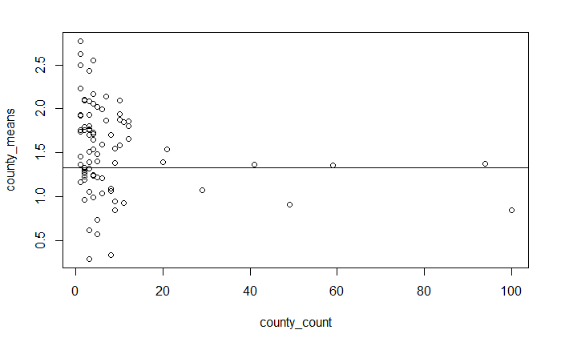

```r
#plot means against counts
plot(county_count,county_means)
#find overall mean and overlay as line
state_mean <- mean(radon_bm$log.radon)
abline(a=state_mean, b=0)
```

2. (15 marks) Using your model, predict for each county in the dataset the log-radon level of a house with a basement. Explain how these predictions have been computed from your model and make a plot with these estimates on the y-axis and the number of observations per county on the x-axis. Add in the plot an horizontal line that represents the average log-radon level of a house with a basement for Minnesota.

```r
#select estimates for parameters as a new vector
pars <- summary(sample)$statistics[,1]
#predict log radon for each county, assuming house has a basement, using model equation
preds <- rep(0, 84)
for(i in 1:84){
  preds[i] <-  pars[1]*pars[i+4] + pars[2]
}
```

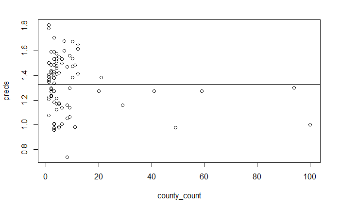

```r
#plot predictions against counts by county
plot(county_count, preds)
abline(a=state_mean, b=0)
```

Values for estimated parameters are substituted into the model equation, drawn from the “pars” vector, to obtain a prediction for each county the log-radon level of a house with a basement.

3. (5 marks) Compare the `naive’ estimates obtained in part 3.a) with the model based estimates obtained in part 3.b). Comment your results.

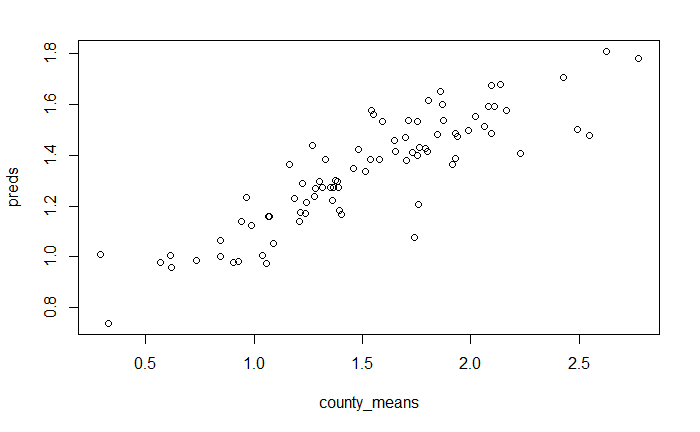

```r
#plot estimates against each other
plot(county_means, preds)
```

```r
#find mean square error of both estimates
mean((county_means-preds)^2)
```

```
[1] 0.1456215
```

```r
##0.144199
#find average log radon for houses with a basement in state
state_mean
```

```
[1] 1.328477
```

```r
##1.328477
##find average predicted log radon for houses with a basement in state
(sum(preds*county_count))/nrow(radon_bm)
```

```
[1] 1.257229
```

```r
##1.257926
```

From the plot, we see from the linear relationship present that the predictions and means are strongly correlated; this is supported by the small value for the MSE. The predictions underestimate the log radon value on average, as can be seen from the prediction average being lower than the observed average, though this is only by a small amount.

4. (15 marks) Provide an answer to the above problem P2, that is use your model to predict the log-radon level of a house with no basement and of a house with a basement located in Cook, given that the soil uranium measurement for this county is equal to -0.504995982525783. Explain how your prediction has been computed from your model.

```r
u_cook <- -0.504995982525783
#Predict the log-radon level of a house with no basement in the county of Cook
pars[1]*u_cook
```

```
     alpha
-0.3186676
```

```r
#Predict the log-radon level of a house with a basement in the county of Cook
pars[1]*u_cook + pars[2]
```

```
    alpha
0.8168436
```

Values for estimated parameters are substituted into the model equation, drawn from the “pars” vector, to obtain a prediction for the log-radon level of a house with no basement and of a house with a basement located in Cook.